# MANCOVA

Multiple numercial Vs. categorical, adapted for covariate

[Dr. Peng Zhao](https://connect.xjtlu.edu.cn/user/pengzhao) (✉ peng.zhao@xjtlu.edu.cn)

Department of Health and Environmental Sciences  
Xi’an Jiaotong-Liverpool University

# 1 Learning objectives

1. Why we use MANCOVA.
2. Explain the results of MANCOVA.

# 2 Principles

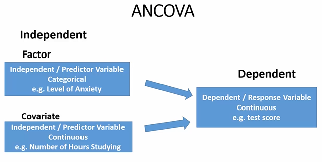

## 2.1 Definition

**Multivariate Analysis of Covariance (MANCOVA):**

= multivariate ANCOVA = MANOVA with covariate(s)

Dependent variables: multiple continuous variables

Independent variables: one or multiple categorical variables, one or multiple continuous variables (covariates)

Analysis for the differences among group means for a linear combination of the dependent variables after adjusted for the covariate

Test whether the independent variable(s) has a significant influence on the dependent variables, excluding the influence of the covariate (preferably highly correlated with the dependent variable)

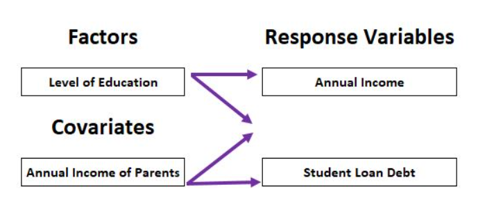

One-way MANCOVA

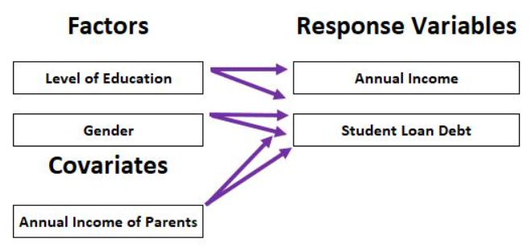

Two-way MANCOVA

## 2.2 Assumptions

- **Independent Random Sampling:** Independence of observations from all other observations.
- **Level and Measurement of the Variables:** The independent variables are categorical and the dependent variables are continuous or scale variables. Covariates are continuous.
- **Homogeneity of Variance:** Variance between groups is equal.
- **Normality**, for each group, each dependent variable follows a normal distribution and any linear combination of dependent variables are normally distributed

# 3 Workflow

## 3.1 Question

- Dependent variables
  - wage (continuous)
  - age (continuous)
- Independent variables
  - education (categorical)
  - year (continuous, covariate)

## 3.2 Visualization

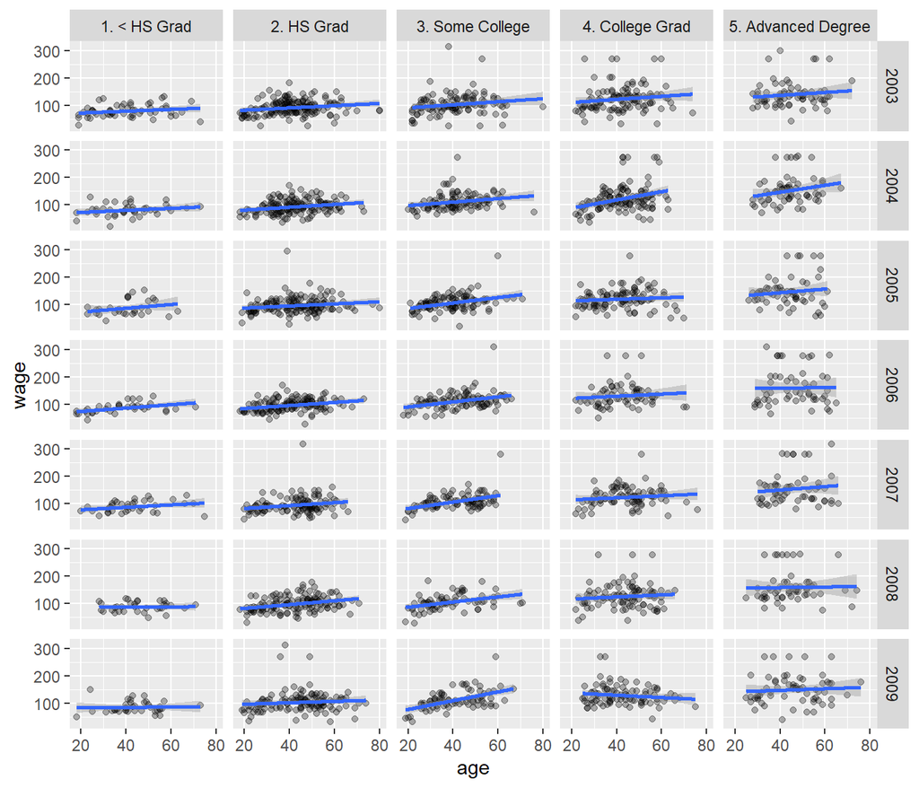

```r
library(tidyverse)
library(ISLR)
library(car)

ggplot(Wage, aes(age, wage))+
  geom_point(alpha = 0.3)+
  geom_smooth(method = lm)+
  facet_grid(year~education)
```

## 3.3 Models

`manova()` or `jmv::mancova()`

```r
wage_manova <- manova(cbind(wage, age) ~ education * year, data = Wage)
wage_manova
```

```
Call:
   manova(cbind(wage, age) ~ education * year, data = Wage)

Terms:
                education    year education:year Residuals
wage              1226364   16807           2404   3976510
age                  4608     494            724    393723
Deg. of Freedom         4       1              4      2990

Residual standard errors: 36.4683 11.47519
Estimated effects may be unbalanced
```

```r
summary.aov(wage_manova)
```

```
 Response wage :
                 Df  Sum Sq Mean Sq  F value    Pr(>F)
education         4 1226364  306591 230.5306 < 2.2e-16 ***
year              1   16807   16807  12.6374  0.000384 ***
education:year    4    2404     601   0.4519  0.771086
Residuals      2990 3976510    1330
---
Signif. codes:  0 '***' 0.001 '**' 0.01 '*' 0.05 '.' 0.1 ' ' 1

 Response age :
                 Df Sum Sq Mean Sq F value    Pr(>F)
education         4   4608 1151.90  8.7477 5.108e-07 ***
year              1    494  494.13  3.7525   0.05282 .
education:year    4    724  180.90  1.3738   0.24043
Residuals      2990 393723  131.68
---
Signif. codes:  0 '***' 0.001 '**' 0.01 '*' 0.05 '.' 0.1 ' ' 1
```

```r
library(jmv)
wage_manova2 <- jmv::mancova(data = Wage,
                             deps = vars(wage, age),
                             factors = education,
                             covs = year)
wage_manova2
```

```
 MANCOVA

 Multivariate Tests
 ─────────────────────────────────────────────────────────────────────────────────────────────
                                      value          F             df1    df2     p
 ─────────────────────────────────────────────────────────────────────────────────────────────
   education    Pillai's Trace        0.240590546    102.353675      8    5988    < .0000001
                Wilks' Lambda           0.7605539    109.739015      8    5986    < .0000001
                Hotelling's Trace     0.313326457    117.184095      8    5984    < .0000001
                Roy's Largest Root    0.308447997    230.873326      4    2994    < .0000001

   year         Pillai's Trace        0.004790217      7.203065      2    2993     0.0007573
                Wilks' Lambda           0.9952098      7.203065      2    2993     0.0007573
                Hotelling's Trace     0.004813274      7.203065      2    2993     0.0007573
                Roy's Largest Root    0.004813274      7.203065      2    2993     0.0007573
 ─────────────────────────────────────────────────────────────────────────────────────────────


 Univariate Tests
 ────────────────────────────────────────────────────────────────────────────────────────────────────────
                Dependent Variable    Sum of Squares    df      Mean Square    F             p
 ────────────────────────────────────────────────────────────────────────────────────────────────────────
   education    wage                    1226364.4849       4    306591.1212    230.699570    < .0000001
                age                        4607.5852       4      1151.8963      8.743336     0.0000005
   year         wage                      16806.9907       1     16806.9907     12.646699     0.0003821
                age                         494.1336       1       494.1336      3.750664     0.0528805
   Residuals    wage                    3978914.2941    2994      1328.9627
                age                      394446.4359    2994       131.7456
 ────────────────────────────────────────────────────────────────────────────────────────────────────────
```

## 3.4 Results

- Since the interaction effect is not significant (p = 0.77 for salary and p = 0.24 for age), the slopes are parallel.
- The wage and age differ significantly among education groups (p for both wage and age are far below 0.05).
- Differences in salary also significantly (p = 0.00038) increase over time (variable year), due to some economic reasons, while differences in age don’t change (p = 0.053) much.

# 4 Further readings

- https://sites.education.miami.edu/statsu/2020/10/16/manova-and-mancova/
- https://yury-zablotski.netlify.app/post/mancova/
- SAGE Publication, 2016. [Multivariate Analysis of Covariance](https://www.simplilearn.com/10-algorithms-machine-learning-engineers-need-to-know-article)